# K-Means Clustering

```python
# See the value of multiple statements at once
# output for all commands in python jupyter notebook

from IPython.core.interactiveshell import InteractiveShell
InteractiveShell.ast_node_interactivity = "all"

# to suppress the warnings
import warnings
warnings.filterwarnings('always')
warnings.filterwarnings('ignore')

# Importing the packages
import numpy as np
import pandas as pd
import matplotlib.pyplot as plt
import seaborn as sns
import time
import os


# This magic command line tells the notebook to show plots inside of the notebook
%matplotlib inline

# set a style/theme to the plots
plt.style.use('tableau-colorblind10')

# for interactive visualizations
import plotly.offline as py
from plotly.offline import init_notebook_mode, iplot
import plotly.graph_objs as go
from plotly import tools
init_notebook_mode(connected = True)
import plotly.figure_factory as ff

# https://plot.ly/python/
```

### Data Info

You are owing a supermarket/mall and through membership cards , you have some basic data about your customers like Customer ID, age, gender, annual income and spending score. Spending Score is something you assign to the customer based on your defined parameters like customer behavior and purchasing data.

#### Problem Statement

You want to understand the customers like who can be easily converge [Target Customers] so that the sense can be given to marketing team and plan the strategy accordingly.

#### Columns

- **CustomerID** Unique ID assigned to the customer
- **Gender** Gender of the customer
- **Age** Age of the customer
- **Annual Income** (k$)Annual Income of the customer
- **Spending Score** (1-100)Score assigned by the mall based on customer behavior and spending nature

```python
# for path
import os
print(os.listdir(r'C:\Users\..'))
```

```python
# Importing the dataset
data = pd.read_csv(r'C:\Users\..\Mall_Customers_data.csv')
```

```python
data.head(10)
```

|  | CustomerID | Gender | Age | Annual Income (k$) | Spending Score (1-100) |
| --- | --- | --- | --- | --- | --- |
| 0 | 1 | Male | 19 | 15 | 39 |
| 1 | 2 | Male | 21 | 15 | 81 |
| 2 | 3 | Female | 20 | 16 | 6 |
| 3 | 4 | Female | 23 | 16 | 77 |
| 4 | 5 | Female | 31 | 17 | 40 |
| 5 | 6 | Female | 22 | 17 | 76 |
| 6 | 7 | Female | 35 | 18 | 6 |
| 7 | 8 | Female | 23 | 18 | 94 |
| 8 | 9 | Male | 64 | 19 | 3 |
| 9 | 10 | Female | 30 | 19 | 72 |

```python
dat = ff.create_table(data.head())

py.iplot(dat)
```

[interactive chart not shown]

```python
desc = ff.create_table(data.describe())
py.iplot(desc)
```

[interactive chart not shown]

```python
# checking if there is any NULL data

data.isnull().any()
```

```
CustomerID                False
Gender                    False
Age                       False
Annual Income (k$)        False
Spending Score (1-100)    False
dtype: bool
```

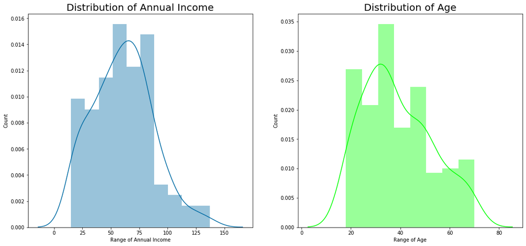

```python
plt.figure(figsize=(18,8))

plt.subplot(1, 2, 1)
sns.distplot(data['Annual Income (k$)']) # , color = 'dodgerblue'
plt.title('Distribution of Annual Income', fontsize = 20)
plt.xlabel('Range of Annual Income')
plt.ylabel('Count')


plt.subplot(1, 2, 2)
sns.distplot(data['Age'], color = 'lime')
plt.title('Distribution of Age', fontsize = 20)
plt.xlabel('Range of Age')
plt.ylabel('Count')
plt.show();
```

We can infer one thing that there are few people who earn more than 100k US Dollars. Most of the people have an earning of around 50-75k US Dollars. Also, we can say that the least Income is around 20k US Dollars.

The most regular customers for the Mall has age around 30-35 years of age. Whereas the the senior citizens age group is the least frequent visitor in the Mall. Youngsters are lesser in umber as compared to the Middle aged people.

```python
x = list(data.Gender.unique())
x.sort()
x
```

```
['Female', 'Male']
```

```python
data['Gender'].value_counts()
```

```
Female    112
Male       88
Name: Gender, dtype: int64
```

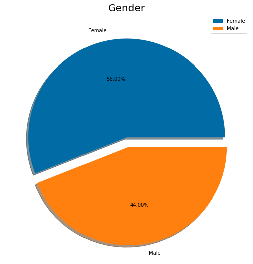

```python
labels = ['Female', 'Male']
size = data['Gender'].value_counts()
#colors = ['coral', 'lime']
explode = [0, 0.1]

# another approach to change the figure size
plt.rcParams['figure.figsize'] = (9, 9)

plt.pie(size,  explode = explode, labels = labels,
        shadow = True, autopct = '%.2f%%') # colors = colors,
plt.title('Gender', fontsize = 20)
plt.axis('off')
plt.legend()
plt.show();
```

Females are in the lead with a share of 56% whereas the Males have a share of 44%, that's a huge gap specially when the population of Males is comparatively higher than Females.

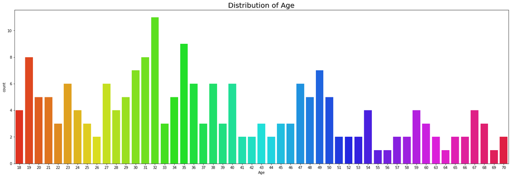

```python
plt.rcParams['figure.figsize'] = (25, 8)
sns.countplot(data['Age'], palette = 'hsv')
plt.title('Distribution of Age', fontsize = 20)
plt.show();
```

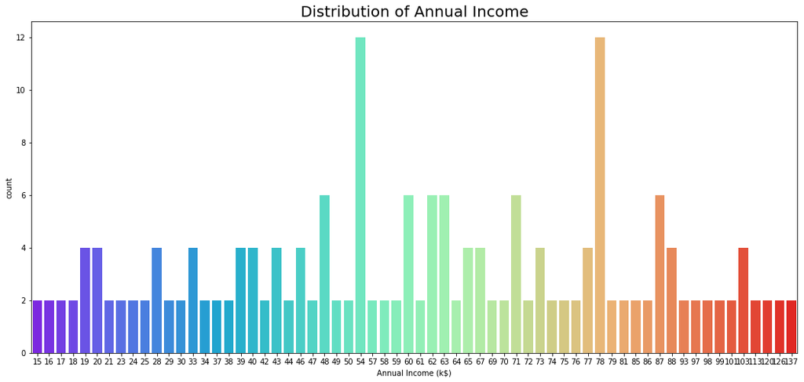

```python
plt.figure(figsize=(18,8))
sns.countplot(data['Annual Income (k$)'], palette = 'rainbow')
plt.title('Distribution of Annual Income', fontsize = 20)
plt.show();
```

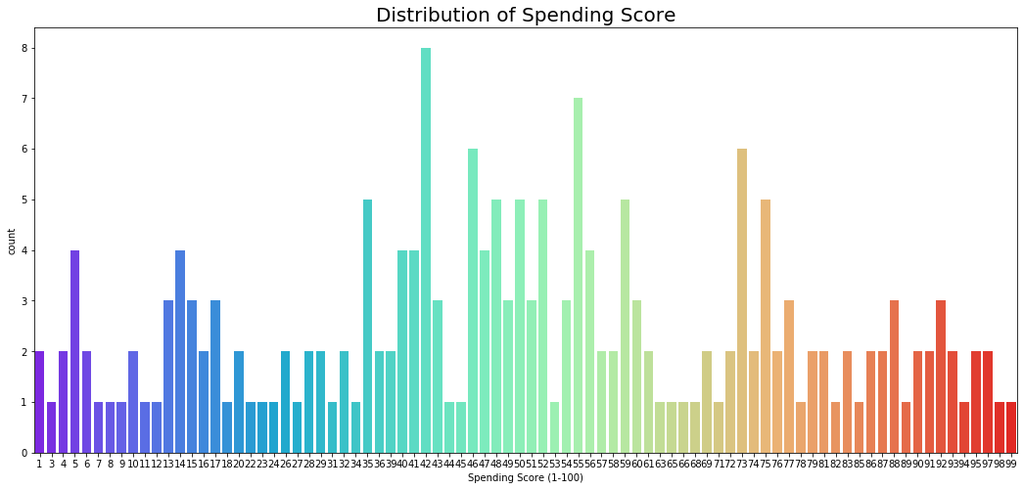

```python
plt.figure(figsize=(18,8))
sns.countplot(data['Spending Score (1-100)'], palette = 'rainbow')
plt.title('Distribution of Spending Score', fontsize = 20)
plt.show();
```

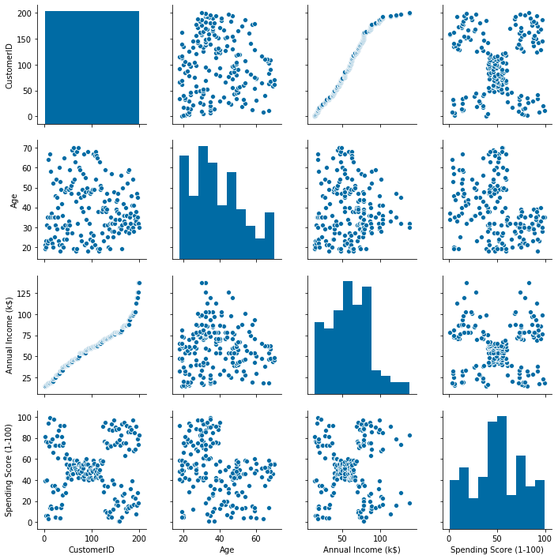

```python
sns.pairplot(data)
plt.show();
```

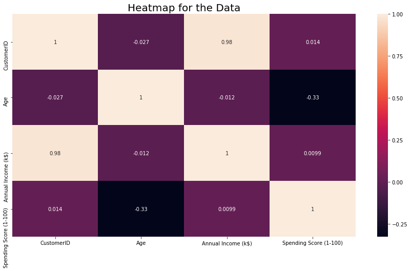

```python
plt.rcParams['figure.figsize'] = (15, 8)
sns.heatmap(data.corr(),  annot = True) # cmap = 'Wistia',
plt.title('Heatmap for the Data', fontsize = 20)
plt.show();
```

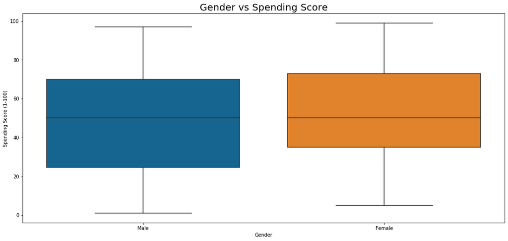

```python
#  Gender vs Spendscore

plt.rcParams['figure.figsize'] = (18, 8)
sns.boxplot(data['Gender'], data['Spending Score (1-100)']) # , palette = 'Wistia'
plt.title('Gender vs Spending Score', fontsize = 20)
plt.show();
```

It is clearly visible that the most of the males have a Spending Score of around 25 to 70 whereas the Females have a spending score of around 35 to 75 which again points to the fact that women are leading.

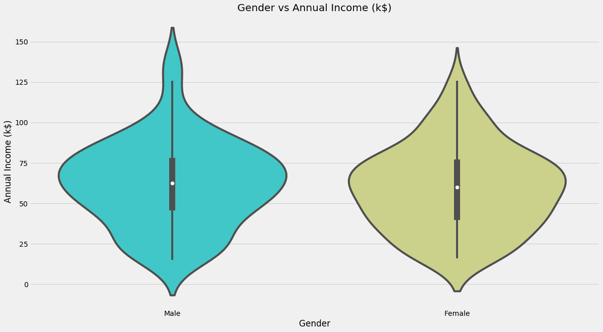

```python
plt.rcParams['figure.figsize'] = (18, 10)
sns.violinplot(data['Gender'], data['Annual Income (k$)'], \
               palette = 'rainbow')
plt.title('Gender vs Annual Income (k$)', fontsize = 20)
plt.show();
```

There are more number of males who get paid more than females. But, The number of males and females are equal in number when it comes to low annual income.

# K-Means Clustering

```python
x = data.iloc[:, [3, 4]].values

# let's check the shape of x
print(x.shape)

pd.DataFrame(x).head()

data.iloc[:, [3, 4]].head()
```

```
(200, 2)
```

|  | 0 | 1 |
| --- | --- | --- |
| 0 | 15 | 39 |
| 1 | 15 | 81 |
| 2 | 16 | 6 |
| 3 | 16 | 77 |
| 4 | 17 | 40 |

|  | Annual Income (k$) | Spending Score (1-100) |
| --- | --- | --- |
| 0 | 15 | 39 |
| 1 | 15 | 81 |
| 2 | 16 | 6 |
| 3 | 16 | 77 |
| 4 | 17 | 40 |

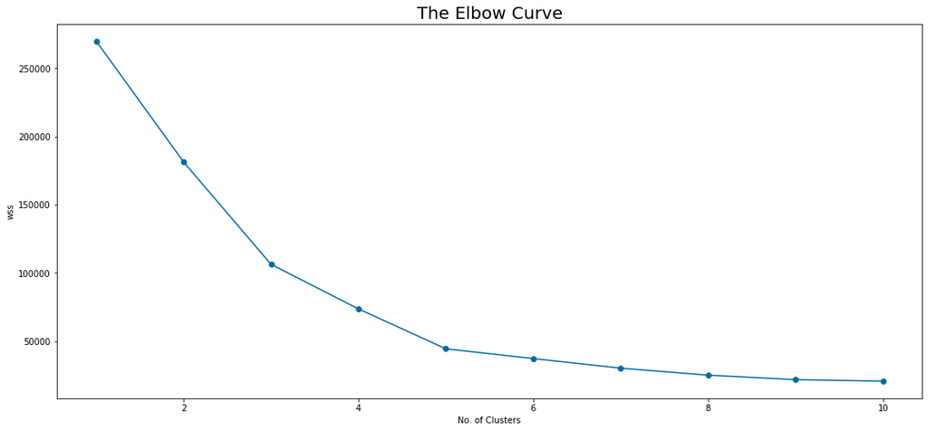

```python
from sklearn.cluster import KMeans

wss = []
for i in range(1, 11):
    km = KMeans(n_clusters = i, random_state = 0)
    km.fit(x)
    wss.append(km.inertia_)
    # inertia_ is the sum of squared dist from closest cluster

plt.figure(figsize=(18,8))
plt.plot(range(1, 11), wss, marker = 'o')
plt.title('The Elbow Curve', fontsize = 20)
plt.xlabel('No. of Clusters')
plt.ylabel('wss')
plt.show();
```

```python
print(km.cluster_centers_)
```

```
[[ 82.38888889  90.44444444]
 [ 28.18181818  33.27272727]
 [ 63.95238095  46.21428571]
 [ 84.46428571  15.32142857]
 [ 25.0952381   80.04761905]
 [ 77.78571429  73.28571429]
 [ 47.86046512  51.97674419]
 [ 24.58333333   9.58333333]
 [114.71428571  78.42857143]
 [124.          17.5       ]]
```

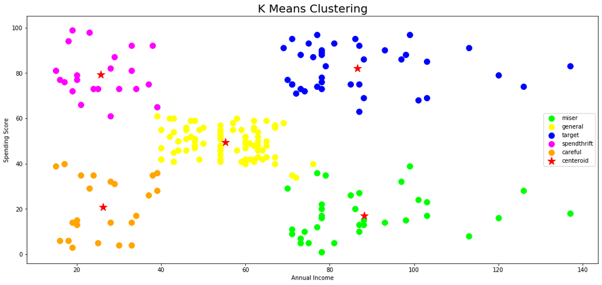

```python
km = KMeans(n_clusters = 5, random_state = 0)
y_means = km.fit_predict(x)

plt.figure(figsize=(18,8))
plt.scatter(x[y_means == 0, 0], x[y_means == 0, 1], s = 100, c = 'lime', label = 'miser')
plt.scatter(x[y_means == 1, 0], x[y_means == 1, 1], s = 100, c = 'yellow', label = 'general')
plt.scatter(x[y_means == 2, 0], x[y_means == 2, 1], s = 100, c = 'blue', label = 'target')
plt.scatter(x[y_means == 3, 0], x[y_means == 3, 1], s = 100, c = 'magenta', label = 'spendthrift')
plt.scatter(x[y_means == 4, 0], x[y_means == 4, 1], s = 100, c = 'orange', label = 'careful')

plt.scatter(km.cluster_centers_[:,0], km.cluster_centers_[:, 1], s = 200, c = 'red' , label = 'centeroid', marker='*')


plt.title('K Means Clustering', fontsize = 20)
plt.xlabel('Annual Income')
plt.ylabel('Spending Score')
plt.legend()
plt.show();
```

# Hierarchial Clustering

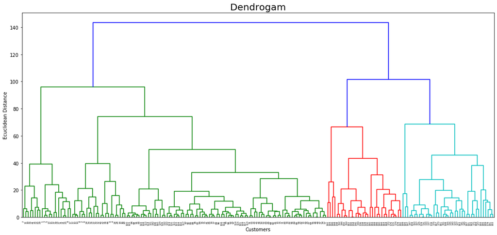

```python
import scipy.cluster.hierarchy as sch

plt.figure(figsize=(18,8))
dendrogram = sch.dendrogram(sch.linkage(x, method = 'complete'))

plt.title('Dendrogam', fontsize = 20)
plt.xlabel('Customers')
plt.ylabel('Ecuclidean Distance')
plt.show();
```

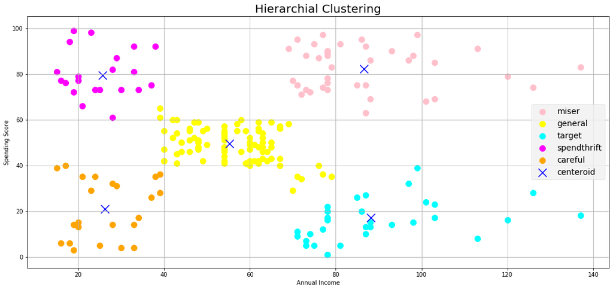

```python
from sklearn.cluster import AgglomerativeClustering

hc = AgglomerativeClustering(n_clusters = 5, affinity = 'euclidean', linkage = 'complete')
y_hc = hc.fit_predict(x)


plt.figure(figsize=(18,8))
plt.scatter(x[y_hc == 0, 0], x[y_hc == 0, 1], s = 100, c = 'pink', label = 'miser')
plt.scatter(x[y_hc == 1, 0], x[y_hc == 1, 1], s = 100, c = 'yellow', label = 'general')
plt.scatter(x[y_hc == 2, 0], x[y_hc == 2, 1], s = 100, c = 'cyan', label = 'target')
plt.scatter(x[y_hc == 3, 0], x[y_hc == 3, 1], s = 100, c = 'magenta', label = 'spendthrift')
plt.scatter(x[y_hc == 4, 0], x[y_hc == 4, 1], s = 100, c = 'orange', label = 'careful')

# the centers are from K-Means..
plt.scatter(km.cluster_centers_[:,0], km.cluster_centers_[:, 1], s = 200, c = 'blue' , label = 'centeroid', marker = 'x')

plt.style.use('fivethirtyeight')
plt.title('Hierarchial Clustering', fontsize = 20)
plt.xlabel('Annual Income')
plt.ylabel('Spending Score')
plt.legend()
plt.grid()
plt.show();
```

## Clusters of Customers Based on their Ages

```python
x = data.iloc[:, [2, 4]].values
x.shape
data.iloc[:, [2, 4]].head()
```

```
(200, 2)
```

|  | Age | Spending Score (1-100) |
| --- | --- | --- |
| 0 | 19 | 39 |
| 1 | 21 | 81 |
| 2 | 20 | 6 |
| 3 | 23 | 77 |
| 4 | 31 | 40 |

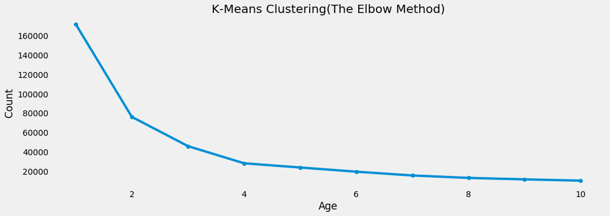

```python
from sklearn.cluster import KMeans

wcss = []
for i in range(1, 11):
    kmeans = KMeans(n_clusters = i, random_state = 0)
    kmeans.fit(x)
    wcss.append(kmeans.inertia_)

plt.rcParams['figure.figsize'] = (15, 5)
plt.plot(range(1, 11), wcss, marker = 'o')
plt.title('K-Means Clustering(The Elbow Method)', fontsize = 20)
plt.xlabel('Age')
plt.ylabel('Count')
plt.grid()
plt.show();
```

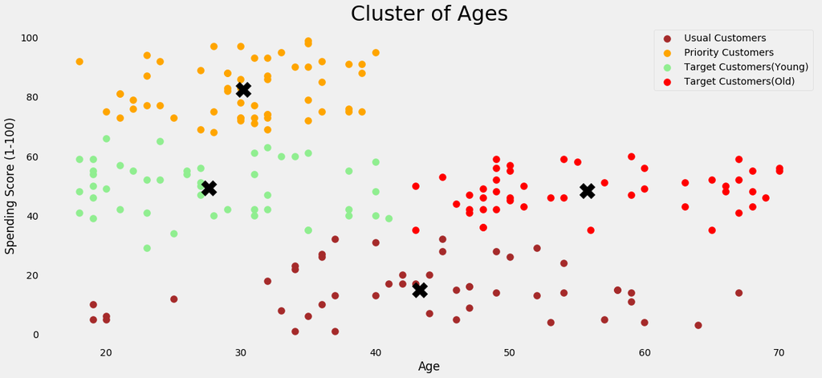

```python
kmeans = KMeans(n_clusters = 4,random_state = 0)
ymeans = kmeans.fit_predict(x)


plt.figure(figsize=(18,8))
plt.title('Cluster of Ages', fontsize = 30)

plt.scatter(x[ymeans == 0, 0], x[ymeans == 0, 1], s = 100, c = 'brown', label = 'Usual Customers' )
plt.scatter(x[ymeans == 1, 0], x[ymeans == 1, 1], s = 100, c = 'orange', label = 'Priority Customers')
plt.scatter(x[ymeans == 2, 0], x[ymeans == 2, 1], s = 100, c = 'lightgreen', label = 'Target Customers(Young)')
plt.scatter(x[ymeans == 3, 0], x[ymeans == 3, 1], s = 100, c = 'red', label = 'Target Customers(Old)')
plt.scatter(kmeans.cluster_centers_[:, 0], kmeans.cluster_centers_[:, 1], s = 500, c = 'black', marker = 'X')

plt.style.use('fivethirtyeight')
plt.xlabel('Age')
plt.ylabel('Spending Score (1-100)')
plt.legend()
plt.grid()
plt.show();
```

```python
x = data[['Age', 'Spending Score (1-100)', 'Annual Income (k$)']].values
km = KMeans(n_clusters = 5, random_state = 0)
km.fit(x)
labels = km.labels_
centroids = km.cluster_centers_
```

```
KMeans(algorithm='auto', copy_x=True, init='k-means++', max_iter=300,
       n_clusters=5, n_init=10, n_jobs=None, precompute_distances='auto',
       random_state=0, tol=0.0001, verbose=0)
```

```python
print(centroids)
```

```
[[45.2173913  20.91304348 26.30434783]
 [32.69230769 82.12820513 86.53846154]
 [43.08860759 49.56962025 55.29113924]
 [40.66666667 17.58333333 87.75      ]
 [25.52173913 78.56521739 26.30434783]]
```

```python
data['labels'] =  labels
trace1 = go.Scatter3d(
    x= data['Age'],
    y= data['Spending Score (1-100)'],
    z= data['Annual Income (k$)'],
    mode='markers',
     marker=dict(
        color = data['labels'],
        size= 10,
        line=dict(
            color= data['labels'],
            width= 12
        ),
        opacity=0.8
     )
)
df = [trace1]

layout = go.Layout(
    title = 'Character vs Gender vs Alive or not',
    margin=dict(
        l=0,
        r=0,
        b=0,
        t=0
    ),
    scene = dict(
            xaxis = dict(title  = 'Age'),
            yaxis = dict(title  = 'Spending Score'),
            zaxis = dict(title  = 'Annual Income')
        )
)

fig = go.Figure(data = df, layout = layout)
py.iplot(fig)
```

[interactive chart not shown]

## Predict new values

```python
km.labels_
```

```
array([0, 4, 0, 4, 0, 4, 0, 4, 0, 4, 0, 4, 0, 4, 0, 4, 0, 4, 0, 4, 0, 4,
       0, 4, 0, 4, 0, 4, 0, 4, 0, 4, 0, 4, 0, 4, 0, 4, 0, 4, 0, 4, 0, 4,
       0, 4, 2, 2, 2, 2, 2, 2, 2, 2, 2, 2, 2, 2, 2, 2, 2, 2, 2, 2, 2, 2,
       2, 2, 2, 2, 2, 2, 2, 2, 2, 2, 2, 2, 2, 2, 2, 2, 2, 2, 2, 2, 2, 2,
       2, 2, 2, 2, 2, 2, 2, 2, 2, 2, 2, 2, 2, 2, 2, 2, 2, 2, 2, 2, 2, 2,
       2, 2, 2, 2, 2, 2, 2, 2, 2, 2, 2, 2, 2, 1, 3, 1, 2, 1, 3, 1, 3, 1,
       3, 1, 3, 1, 3, 1, 3, 1, 3, 1, 2, 1, 3, 1, 3, 1, 3, 1, 3, 1, 3, 1,
       3, 1, 3, 1, 3, 1, 3, 1, 3, 1, 3, 1, 3, 1, 3, 1, 3, 1, 3, 1, 3, 1,
       3, 1, 3, 1, 3, 1, 3, 1, 3, 1, 3, 1, 3, 1, 3, 1, 3, 1, 3, 1, 3, 1,
       3, 1])
```

```python
sample_test=np.array([22,79,17])
sample_test=sample_test.reshape(1, -1)

km.predict(np.array([22,79,17]).reshape(1,-1))
```

```
array([4])
```

```python
km.predict(np.array([22,79,17,31,40,17]).reshape(2,3))
```

```
array([4, 0])
```

```python
data.tail()
```

|  | CustomerID | Gender | Age | Annual Income (k$) | Spending Score (1-100) | labels |
| --- | --- | --- | --- | --- | --- | --- |
| 195 | 196 | Female | 35 | 120 | 79 | 1 |
| 196 | 197 | Female | 45 | 126 | 28 | 3 |
| 197 | 198 | Male | 32 | 126 | 74 | 1 |
| 198 | 199 | Male | 32 | 137 | 18 | 3 |
| 199 | 200 | Male | 30 | 137 | 83 | 1 |

```python
km.predict(np.array([22,79,17,30,83,137]).reshape(2,3))
```

```
array([4, 1])
```